# Fallstudie Iris

Manfred Brill

# 1 Der Datensatz *Iris*

Dieser Datensatz ist in R einfach verfügbar, im Package *datasets*, das bereits beim Start geladen wird. Der Datensatz ist als data.frame *iris* verfügbar. Diese Variable enthält 150 Zeilen und 5 Spalten. Die ersten vier Spalten enthalten die Messwerte, in Spalte 5 finden wir die Angabe über die Spezies. Als Messwerte liegen Angaben über die Länge und Breite von Kelch- und Kronblatt vor. Im Datensatz finden wir diese Angaben als *Petal* und *Sepal*.

Wir stellen sicher, dass diese Spalte ein Faktor ist. Da wir später klassifizieren möchten erzeugen wir einen Tibble, der die Information über die Spezies nicht mehr enthält.

```r
iris$Species <- as_factor(iris$Species)

irisValues <- iris[,-5]
```

In der folgenden Tabelle finden wir die ersten 6 Zeilen des Datensatzes. Insgesamt liegen 150 Zeilen vor, dabei gehören jeweils 50 zu jeder der drei Spezies.

Tabelle 1: Die ersten Werte im Datensatz Iris

| Sepal.Length | Sepal.Width | Petal.Length | Petal.Width | Species |
| --- | --- | --- | --- | --- |
| 5.1 | 3.5 | 1.4 | 0.2 | setosa |
| 4.9 | 3.0 | 1.4 | 0.2 | setosa |
| 4.7 | 3.2 | 1.3 | 0.2 | setosa |
| 4.6 | 3.1 | 1.5 | 0.2 | setosa |
| 5.0 | 3.6 | 1.4 | 0.2 | setosa |
| 5.4 | 3.9 | 1.7 | 0.4 | setosa |

Die folgende Darstellung der Verfahren orientiert sich an (Gareth et al. 2013) und (Kabacoff 2015).

# 2 Visualisierungen

## 2.1 Streuungsdiagramme

Wir erzeugen einige Streuungsdiagramme, um die vier möglichen Merkmale und ihren Zusammenhang zu visualisieren.

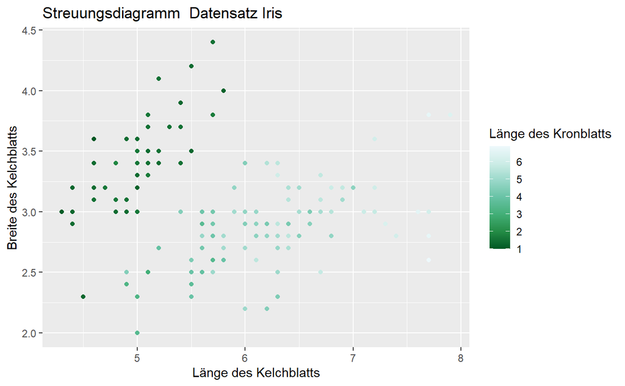

```r
ggplot(iris) +
  geom_point(mapping=aes(x = Sepal.Length,
                         y = Sepal.Width,
                         color = Petal.Length)) +
  scale_x_continuous(breaks = seq(0.0, 8.0)) +
  scale_color_distiller(palette="BuGn") +
  labs(
         title="Streuungsdiagramm  Datensatz Iris",
         x = "Länge des Kelchblatts",
         y = "Breite des Kelchblatts",
         color = "Länge des Kronblatts"
  )

ggsave(filename="irisScatterSepalPetal.png",
       plot=last_plot(),
       device="png",
       path="images/",
       width=16,
       height=9,
       units="cm")
```

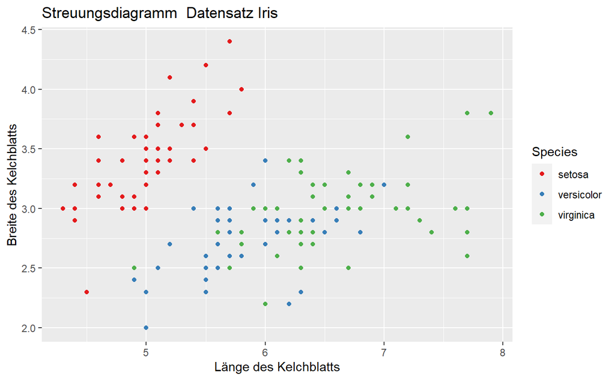

```r
ggplot(iris) +
  geom_point(mapping=aes(x = Sepal.Length,
                         y = Sepal.Width,
                         color = Species)) +
  scale_x_continuous(breaks = seq(0.0, 8.0)) +
  scale_color_brewer(palette = "Set1") +
  labs(
         title="Streuungsdiagramm  Datensatz Iris",
         x = "Länge des Kelchblatts",
         y = "Breite des Kelchblatts"
  )

ggsave(filename="irisScatterSepal.png",
       plot=last_plot(),
       device="png",
       path="images/",
       width=16,
       height=9,
       units="cm")
```

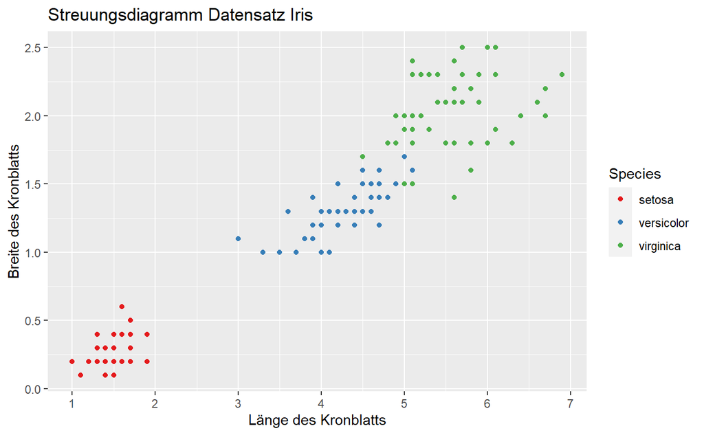

```r
petal.Plot <- ggplot(iris) +
  geom_point(mapping=aes(x = Petal.Length,
                         y = Petal.Width,
                         color = Species)) +
  scale_x_continuous(breaks = seq(0.0, 8.0)) +
  scale_color_brewer(palette = "Set1") +
  labs(
         title="Streuungsdiagramm Datensatz Iris",
         x = "Länge des Kronblatts",
         y = "Breite des Kronblatts"
  )

petal.Plot

ggsave(filename="irisScatterPetal.png",
       plot=last_plot(),
       device="png",
       path="images/",
       width=16,
       height=9,
       units="cm")
```

## 2.2 SPLOM

Wir erzeugen eine Scatterplot-Matrix für den Datensatz. Hier sehen wir schon, dass wir Iris Setosa gut von den beiden anderen Spezies unterscheiden können. Dazu verwenden wir die Funktion *ggpairs* im Package *GGally*, einer Erweiterung von *ggplot*.

```r
ggpairs(iris,
        columns=1:4,
        title="Scatterplot-Matrix für den Datensatz Iris",
        aes(color = Species),
        legend = c(2,1),
        diag = "blank",
        upper = "blank")
```

[output not shown]

[output not shown]

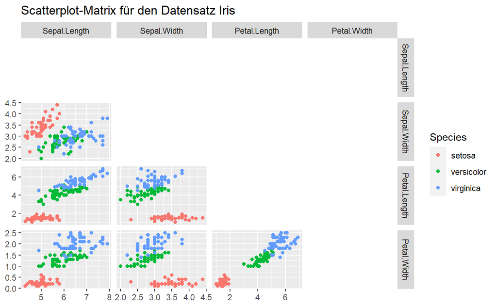

```r
ggsave(filename="irisggSPLOM.png",
       plot=last_plot(),
       device="png",
       path="images/",
       width=16,
       height=9,
       units="cm")
```

# 3 Eine naive Klassifizierung

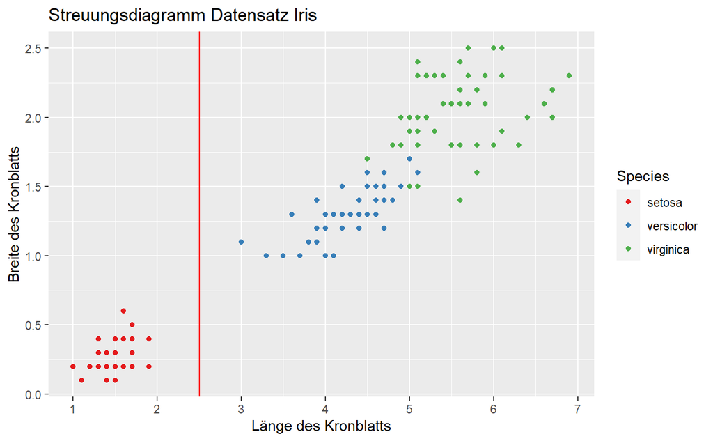

```r
petal.Plot +
  geom_vline(xintercept=2.5, color="red")

ggsave(filename="irisScatterPetalab.png", plot=last_plot(),
       device="png",
       path="images/",
       width=16,
       height=9,
       units="cm")
```

```r
NA
```

Die beiden anderen Spezies korrekt zu trennen wir deutlich schwieriger. Dies ist mit ein Grund weshalb Iris einer der Datensätze ist, die man für Klassifizierungsverfahren verwendet um die Performanz zu evaluieren.

Wir verwenden diese Beobachtung und klassifizieren den die 150 Zeilen des Datensatzes. Als erste Regel können wir untersuchen, ob Petal.Length <= 2.5 für ein Exemplar erfüllt ist oder nicht. Falls ja, dann sagen wir als Spezies dieses Exemplars Iris Setosa voraus.

Wenn wir für die Exemplare mit Petal.Length > 2.5 weiter mit Petal.Length > 4.8 unterscheiden und als Spezies Iris Versicolor setzen, wenn diese zweite Bedingung verletzt ist und Iris Virginica voraussagen, falls der Vergleich wahr ist, dann haben wir den Versuch einer Klassifizierung. Wir erstellen ein weiteres Streuungsdiagramm, in das wir die zweite Entscheidungsgrenzen ebenfalls einzeichnen.

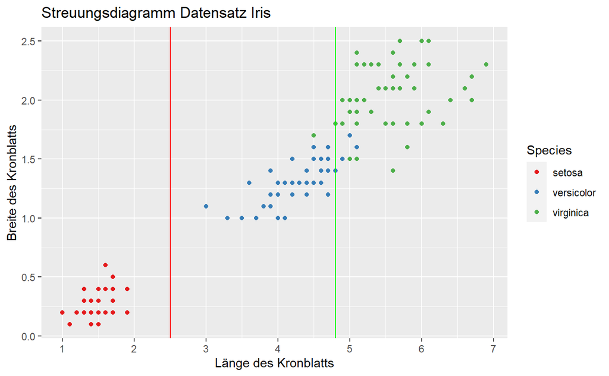

```r
petal.Plot +
  geom_vline(xintercept=2.5, color="red") +
  geom_vline(xintercept=4.8, color="green")

ggsave(filename="irisScatterPetalab2.png", plot=last_plot(),
       device="png",
       path="images/",
       width=16,
       height=9,
       units="cm")
```

Wir schreiben R-Code für diese Überlegung und implementieren eine Funktion, der wir einen Index zwischen 1 und 150 übergeben, mit dessen Hilfe wir eine Zeile aus dem Iris-Datensatz auswählen. Wir schreiben noch eine weitere Funktion mit deren Hilfe wir überprüfen können, ob die Vorhersage korrekt ist.

```r
classifier <- function(i, barrier.Setosa = 2.5, barrier.Virginica = 4.8) {

  if (iris[i, 3] <= barrier.Setosa) {
    return("setosa")
  }
  else if (iris[i, 3] <= barrier.Virginica) {
    return("versicolor")
  }
  else
    return("virginica")
}

checkPrediction <- function(i, prediction) {
  if (prediction == iris[i, 5]) {
    print("Vorhersage korrekt!")
    }
  else {
    print("Vorhersage falsch!")
  }
}
```

Wir können jetzt eine Zeile auswählen und mit der Funktion eine Vorhersage ausgeben. Wir wissen aus der Dokumentation, dass die ersten 50 Zeile immer die Spezies *Setosa* enthält. Also müssen wir für die Werte unserer Schranken und i=2 die korrekte Vorhersage erhalten:

```r
i <- 2
predict <- classifier(i)
checkPrediction(i, predict)
```

```
[1] "Vorhersage korrekt!"
```

```r
i <- 55
predict <- classifier(i)
checkPrediction(i, predict)
```

```
[1] "Vorhersage korrekt!"
```

Jetzt verwenden wir die Funktion *map_chr*, um in einer Schleife über alle indizes zwischen 1 und 150 alle Zeilen vorherzusagen. Anschließend vergleichen wir diese Ergebnisse mit dem korrekten Ergebnis. Den Vergleich zwischen den korrekten Werten und der Vorhersage geben wir in der sogenannten *confusion matrix* aus. Dazu verwenden wir die Funktion *table*.

```r
predictions <- seq(1, 150) %>%
  map_chr(classifier)

correct <- c(rep("setosa", 50), rep("versicolor", 50), rep("virginica", 50))

confusion <- table(correct, predictions)
confusion
```

```
            predictions
correct      setosa versicolor virginica
  setosa         50          0         0
  versicolor      0         46         4
  virginica       0          3        47
```

In den Spalten sehen wir die Vorhersagen, in den Zeilen die korrekten Werte. Wären alle Vorhersagen korrekt, dann hätten wir eine Diagonalmatrix und immer den Wert 50 in der Diagonale. Für Iris Setosa ist dies auch so. Wir hatten bereits vermutet, dass wir mit dem ersten Vergleich in unserer Funktion immer korrekt Iris Setosa erkennen. Der zweite Vergleich war etwas willkürlich, schon im Streuungsdiagramm konnten wir erkennen, dass es Fälle geben wird, in den denen wir uns hier falsch entscheiden. Das zeigen uns auch die zweite und die dritte Spalte der confusion matrix. Die zweite Zeile sagt uns, dass es vier Exemplare Iris Versicolor gibt, die fälschlicher Weise als Iris Virginica klassifizert werden. Und es gibt 3 Exemplare der Spezies Iris Virginica, die als Iris Versicolor eingeteilt werden.

Wir können den mittleren Fehler bei diesen 150 Tests berechnen. Dazu bilden wir einen Vektor, in den wir eine 1 schreiben wenn die Vorhersage falsch ist und 0 für eine korrekte Einteilung.

```r
naiveError <- mean(correct != predictions)
```

Für unser Ergebnis erhalten wir einen Testfehler von 0.047.

Die confusion matrix können wir gut als Heatmap visualisieren. Wenn wir ggplot verwenden möchten müssen wir die Matrix in das *long*-Format umwandeln und anschließend das geom *geom_tile* einsetzen.

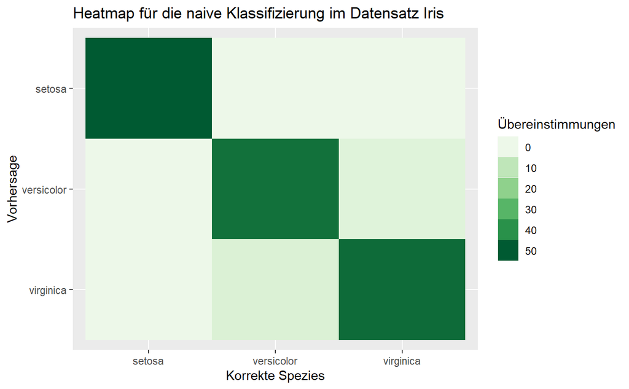

```r
# Geänderte Reihenfolge auf der y-Achse
# quelle: https://stackoverflow.com/questions/
# 12774210/how-do-you-specifically-order-ggplot2-x-axis-instead-of-alphabetical-order
level_order <- c("virginica", "versicolor", "setosa")

confusion %>%
  as_tibble() %>%
  ggplot() +
  geom_tile(mapping=aes(x=correct,
                        y=factor(predictions, level=level_order),
                        fill=n)) +
  scale_fill_distiller(palette="Greens",
                       guide="legend",
                       limits = c(0, 50),
                       direction=1) +
  guides(fill=guide_legend(title="Übereinstimmungen")) +
  labs(
    title="Heatmap für die naive Klassifizierung im Datensatz Iris",
    x="Korrekte Spezies",
    y="Vorhersage"
  )
```

Vergleicht man die Grafik mit der confusion matrix, verwendet die Heatmap die falsche Reihenfolge auf der y-Achse. Das können wir mit Hilfe von *scale_y_discrete* korrigieren.

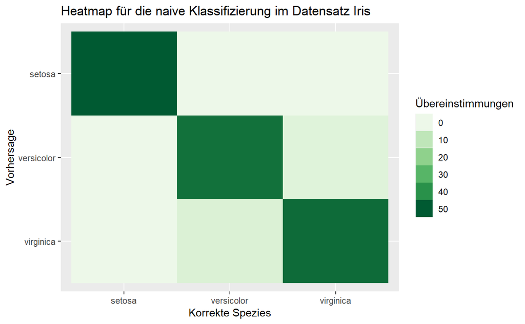

```r
confusion %>%
  as_tibble() %>%
  ggplot() +
  geom_tile(mapping=aes(x=correct,
                        y=factor(predictions, level=level_order),
                        fill=n)) +
  scale_fill_distiller(palette="Greens",
                       guide="legend",
                       limits = c(0, 50),
                       direction=1) +
  scale_y_discrete(breaks = c("virginica", "versicolor", "setosa")) +
  guides(fill=guide_legend(title="Übereinstimmungen")) +
  labs(
    title="Heatmap für die naive Klassifizierung im Datensatz Iris",
    x="Korrekte Spezies",
    y="Vorhersage"
  )


ggsave(filename="irisNaiveHeat.png", plot=last_plot(),
       device="png",
       path="images/",
       width=16, height=9, units="cm")
```

# 4 Klassifizierung mit dem knn-Verfahren

Es gibt eine ganze Menge von Verfahren, die wir im machine learning für die Klassifizierung einsetzen können. Als erstes betrachten wir das knn-Verfahren. Dabei steht *knn* für *k-nearest neighbours*. Da das knn-Verfahren sich etwas von den anderen Verfahren unterscheidet betrachten wir die restlichen Verfahren im nächsten Abschnitt.

So wie das knn-Verfahren vorgeht gibt es also keinen Trainings-Fehler, sondern nur einen Test-Fehler. Aber das ist sowieso der interessante Fehler, den wir interpretieren möchten. Das Verfahren ist als Funktion *knn* im Package *class* enthalten. Wir laden dieses Package und verwenden jeweils 40 der drei Spezies als Trainingsmenge. Dazu erzeugen wir 40 Zufallszahlen zwischen 1 und 50. Man könnte auch darauf verzichten, eine gleiche Anzahl von Samples aus jeder Spezies zu verwenden und einfach 120 Zeilen zufällig auswählen. Aber da wir uns auf der Prinzip des Verfahrens konzentrieren möchten verzeichten wir darauf. Für die Erzeugung der Zufallszahlen verwenden wir wieder einen seed-Value, um die Ergebnisse in dieser Datei reproduzierbar zu machen. Darauf verzichten Sie natürlich bei einer realen Anwendung.

```r
library(class)
train.n <- 40
set.seed(42)
setosa.ran <- sample(1:50, train.n)
versicolor.ran <- setosa.ran + 50
virginica.ran <- setosa.ran + 100

train.set <- c(setosa.ran, versicolor.ran, virginica.ran)
train <- iris[train.set, 1:4]
# Wir benötigen die Spezies der Trainingsmenge als Vektor
train.species <- iris[train.set, 5]

test <- iris[-train.set,1:4]
# Wir speichern auch die korrekten Spezies unserer Testmenge
# für die Berechnung des Testfehlers
correct <- iris[-train.set, 5]

k <- 5
predictions <- knn(train, test, train.species, k)

confusion <- table(correct, predictions)
confusion
```

```
            predictions
correct      setosa versicolor virginica
  setosa         10          0         0
  versicolor      0          9         1
  virginica       0          0        10
```

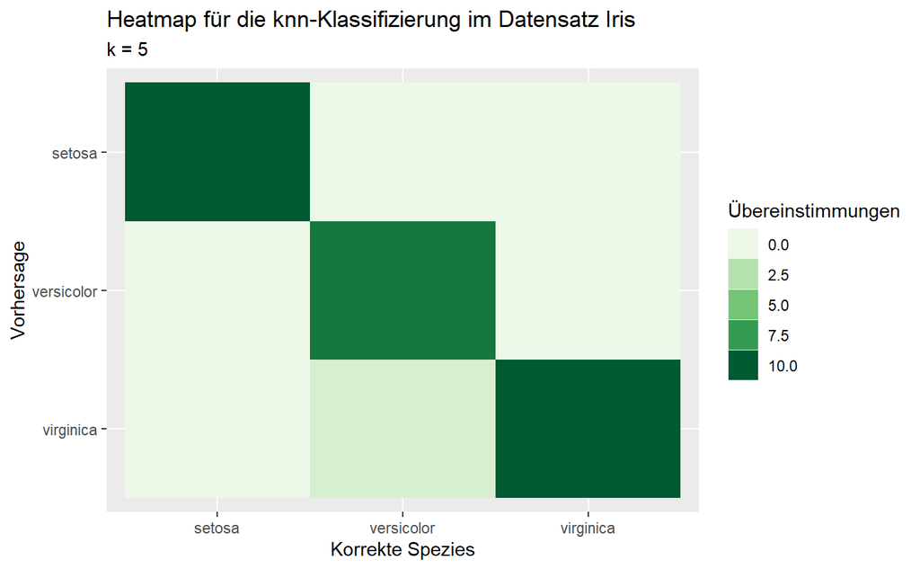

```r
testError <- mean(correct != predictions)

confusion %>%
  as_tibble() %>%
  ggplot() +
  geom_tile(mapping=aes(x=correct,
                        y=factor(predictions, level=level_order),
                        fill=n)) +
  scale_fill_distiller(palette="Greens",
                       guide="legend",
                       limits = c(0, 10),
                       direction=1) +
  guides(fill=guide_legend(title="Übereinstimmungen")) +
  labs(
    title="Heatmap für die knn-Klassifizierung im Datensatz Iris",
    subtitle="k = 5",
    x="Korrekte Spezies",
    y="Vorhersage"
  )


ggsave(filename="irisknnHeat.png", plot=last_plot(),
       device="png",
       path="images/",
       width=16, height=9, units="cm")
```

```r
k <- 3

predictions <- knn(train, test, train.species, k)

confusion <- table(correct, predictions)
confusion
```

```
            predictions
correct      setosa versicolor virginica
  setosa         10          0         0
  versicolor      0          9         1
  virginica       0          0        10
```

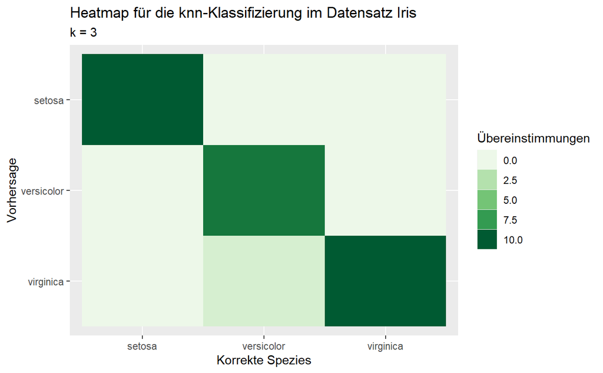

```r
testError.3 <- mean(correct != predictions)

confusion %>%
  as_tibble() %>%
  ggplot() +
  geom_tile(mapping=aes(x=correct,
                        y=factor(predictions, level=level_order),
                        fill=n)) +
  scale_fill_distiller(palette="Greens",
                       guide="legend",
                       limits = c(0, 10),
                       direction=1) +
  guides(fill=guide_legend(title="Übereinstimmungen")) +
  labs(
    title="Heatmap für die knn-Klassifizierung im Datensatz Iris",
    subtitle="k = 3",
    x="Korrekte Spezies",
    y="Vorhersage"
  )

ggsave(filename="irisknnHeat3.png", plot=last_plot(),
       device="png",
       path="images/",
       width=16, height=9, units="cm")
```

```r
k <- 13

predictions <- knn(train, test, train.species, k)

confusion <- table(correct, predictions)
confusion
```

```
            predictions
correct      setosa versicolor virginica
  setosa         10          0         0
  versicolor      0          9         1
  virginica       0          1         9
```

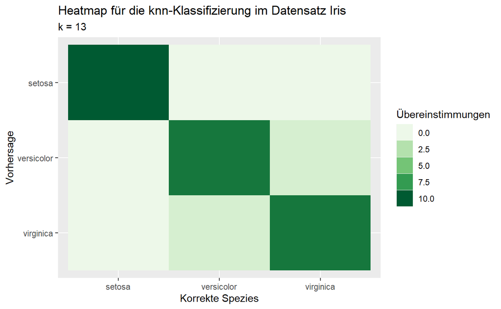

```r
testError.13 <- mean(correct != predictions)

confusion %>%
  as_tibble() %>%
  ggplot() +
  geom_tile(mapping=aes(x=correct,
                        y=factor(predictions, level=level_order),
                        fill=n)) +
  scale_fill_distiller(palette="Greens",
                       guide="legend",
                       limits = c(0, 10),
                       direction=1) +
  guides(fill=guide_legend(title="Übereinstimmungen")) +
  labs(
    title="Heatmap für die knn-Klassifizierung im Datensatz Iris",
    subtitle="k = 13",
    x="Korrekte Spezies",
    y="Vorhersage"
  )

ggsave(filename="irisknnHeat13.png", plot=last_plot(),
       device="png",
       path="images/",
       width=16, height=9, units="cm")
```

Für den Wert 3 für k erhalten wir einen Testfehler von 0.033. Den gleichen Wert wie für k=5. Für den größeren Wert k=13 erhalten wir einen Testfehler von 0.067. Es gibt eine optimale Wahl für k, meist reichen kleinere Werte wie im Beispiel aus. Auf jeden Fall haben wir mit Hilfe eines Verfahrens eine bessere Klassifizierung wie für unseren naiven Ansatz gefunden.

Wir untersuchen die Qualität des knn-Verfahrens weiter und erstellen Streuungsdiagramme, in denen wir die Testmenge einmal mit korrekter Klassifizierung und mit Entscheidung aus dem Algorithmus visualiseren.

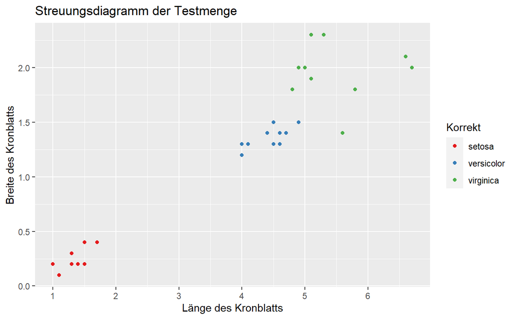

```r
ggplot(test) +
  geom_point(mapping=aes(x = Petal.Length, y = Petal.Width, color = correct)) +
  scale_x_continuous(breaks = seq(0.0, 8.0)) +
  scale_color_brewer(palette = "Set1") +
  guides(color=guide_legend(title="Korrekt")) +
  labs(
         title="Streuungsdiagramm der Testmenge",
         x = "Länge des Kronblatts",
         y = "Breite des Kronblatts"
  )

ggsave(filename="irisScatterPetalCorrect.png", plot=last_plot(),
       device="png",
       path="images/",
       width=16,
       height=9,
       units="cm")
```

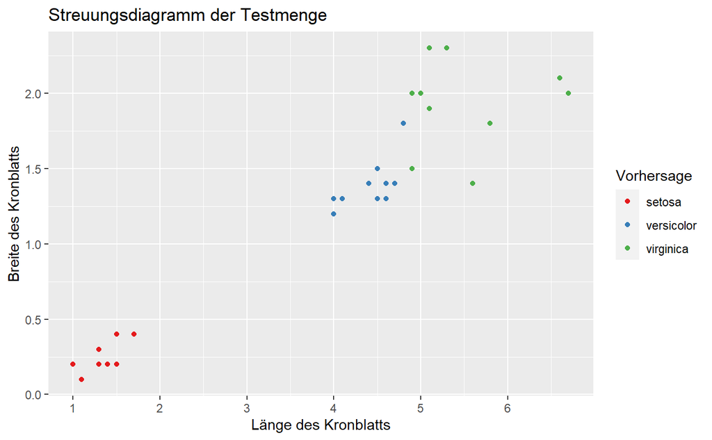

```r
ggplot(test) +
  geom_point(mapping=aes(x = Petal.Length, y = Petal.Width, color = predictions)) +
  scale_x_continuous(breaks = seq(0.0, 8.0)) +
  scale_color_brewer(palette = "Set1") +
  guides(color=guide_legend(title="Vorhersage")) +
  labs(
         title="Streuungsdiagramm der Testmenge",
         x = "Länge des Kronblatts",
         y = "Breite des Kronblatts"
  )

ggsave(filename="irisScatterPetalPred.png", plot=last_plot(),
       device="png",
       path="images/",
       width=16,
       height=9,
       units="cm")
```

# 5 Klassifizierungsalgorithmen

## 5.1 Entscheidungsbäume

Unser naiver Ansatz war durch zwei if-Anweisungen geben. Das können wir leicht als einen Baum visualisieren, an dessen Blätter die vorhergesagten Spezies zu finden sind. Genauso solche Bäume versucht der Algorithmus zu konstruieren, der in der Literatur unter der Bezeichnung *decision trees* zu finden ist.

Die Bäume, die mit diesem Algorithmus erzeugt werden sind häufig zu tief. Deshalb verwendet man ein *pruning*, das die Bäume wieder etwas kleiner macht, um ein over-fitting zu vermeiden. Wir finden diesen Algorithmus im Package *rpart*, das wir im ersten Schritt laden. Die Bäume werden mit Hilfe von zufälligen Entscheidungen konstruiert, so dass wir hier auch wieder *set.seed* verwenden.

```r
library(rpart)
set.seed(42)

# Wir benötigen die Spalte 5 für glm
train <- iris[train.set,]

test <- iris[-train.set,]

dtree <- rpart(Species ~ Sepal.Length+Sepal.Width+Petal.Length+Petal.Width,
    data = train,
    method = "class",
    parms=list(split="information")
)

dtree$cptable
```

```
     CP nsplit rel error xerror   xstd
1 0.500      0    1.0000  1.175 0.0564
2 0.438      1    0.5000  0.650 0.0679
3 0.010      2    0.0625  0.112 0.0361
```

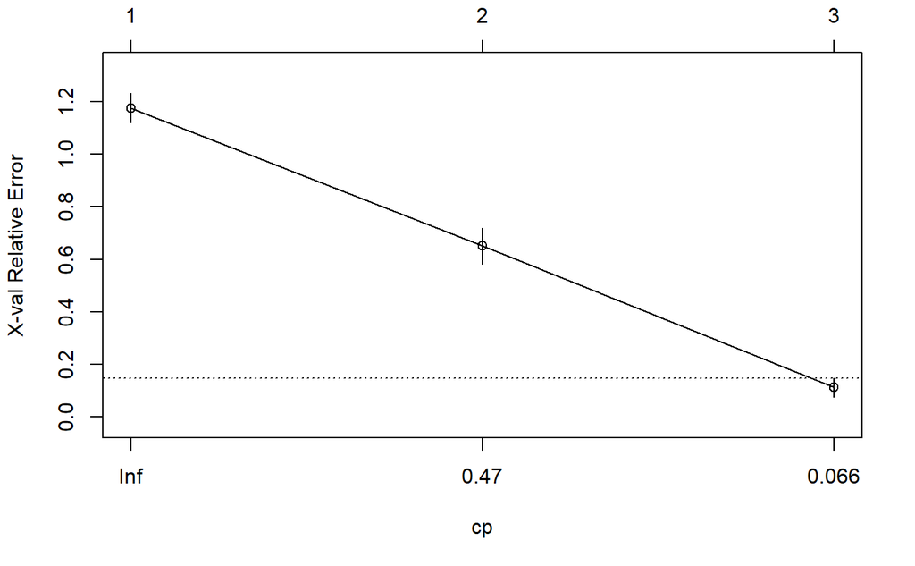

```r
plotcp(dtree)
```

```r
dtree.pruned <- prune(dtree, cp = 0.01)

predictions <- predict(dtree.pruned, test, type="class")
confusion <- table(correct, predictions)

confusion
```

```
            predictions
correct      setosa versicolor virginica
  setosa         10          0         0
  versicolor      0         10         0
  virginica       0          1         9
```

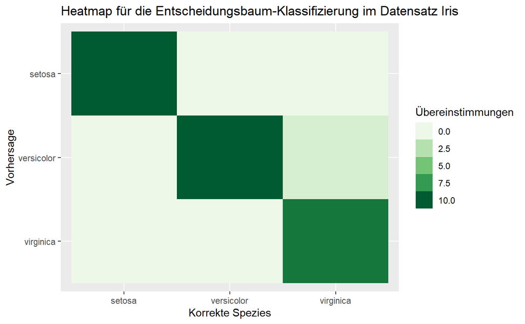

```r
testError <- mean(correct != predictions)

confusion %>%
  as_tibble() %>%
  ggplot() +
  geom_tile(mapping=aes(x=correct,
                        y=factor(predictions, level=level_order),
                        fill=n)) +
  scale_fill_distiller(palette="Greens",
                       guide="legend",
                       limits = c(0, 10),
                       direction=1) +
  guides(fill=guide_legend(title="Übereinstimmungen")) +
  labs(
    title="Heatmap für die Entscheidungsbaum-Klassifizierung im Datensatz Iris",
    x="Korrekte Spezies",
    y="Vorhersage"
  )
```

## 5.2 Random Forests

Häufig sind die Entscheidungsbäume, die wir mit *rpart* konstruieren unhandlich und nicht performant. Deshalb wurd der Algorithmus *random forests* vorgeschlagen, In diesem Verfahren erzeugen wir eine größere Anzahl von kleineren Entscheidungsbäumen und bilden am Ende eine Mehrheitsentscheidung, welche Spezies wir vorhersagen. In der Praxis ist dieses Verfahren häufig deutlich besser als ein einzelner Entscheidungsbaum. Die Funktion dafür finden wir im Package *randomForest*. Achten Sie darauf, dass dieses Notebook voraussetzt, dass dieses Package installiert ist.

```r
library(randomForest)
set.seed(42)
fit.forest <- randomForest(Species ~ Sepal.Length+Sepal.Width+Petal.Length+Petal.Width,
    data = train,
    na.action = na.roughfix,
    importance = TRUE
)

predictions <- predict(fit.forest, test)
confusion <- table(correct, predictions)

confusion
```

```
            predictions
correct      setosa versicolor virginica
  setosa         10          0         0
  versicolor      0         10         0
  virginica       0          0        10
```

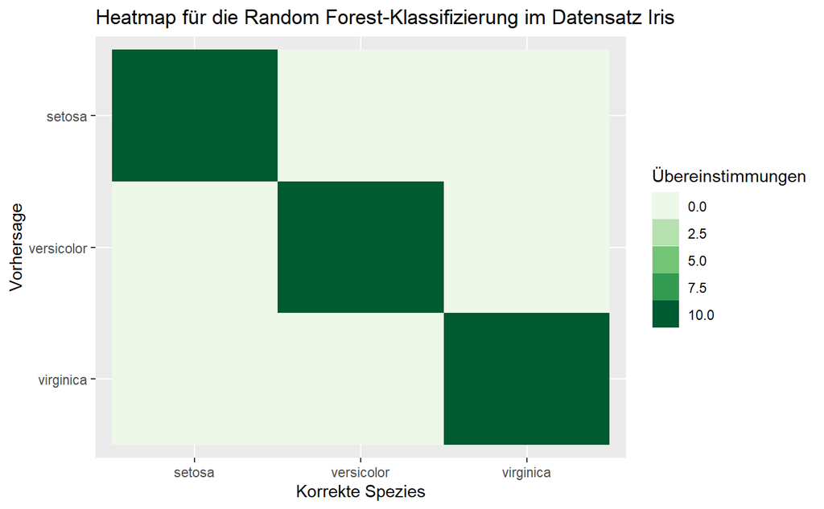

[figure not shown]

```r
testError <- mean(correct != predictions)

confusion %>%
  as_tibble() %>%
  ggplot() +
  geom_tile(mapping=aes(x=correct,
                        y=factor(predictions, level=level_order),
                        fill=n)) +
  scale_fill_distiller(palette="Greens",
                       guide="legend",
                       limits = c(0, 10),
                       direction=1) +
  guides(fill=guide_legend(title="Übereinstimmungen")) +
  labs(
    title="Heatmap für die Random Forest-Klassifizierung im Datensatz Iris",
    x="Korrekte Spezies",
    y="Vorhersage"
  )

ggsave(filename="irisranForHeat.png", plot=last_plot(),
       device="png",
       path="images/",
       width=16, height=9, units="cm")
```

Der Testfehler ist hier 0, alle Spezies werden korrekt vorhergesagt.

## 5.3 Support Vector Machines

Es gibt eine ganze Reihe von Algorithmen, die versuchen eine Entscheidungsgrenze zwischen den Spezies zu berechnen. Dazu zählen Verfahren wie *LDA* oder *QDA*. Hier werfen wir noch einen schnellen Blick auf *Support Vector Machines* oder kurz *SVM*. Dieses Verfahren hat häufig eine sehr gute Performanz. Wir laden dazu das Package *e1071*, in dem die Funktion *svm* zu finden ist.

```r
library(e1071)

set.seed(42)
svm.fit <- svm(Species ~ Sepal.Length+Sepal.Width+Petal.Length+Petal.Width,
    data = train)

predictions <- predict(fit.forest, test)
confusion <- table(correct, predictions)

confusion
```

```
            predictions
correct      setosa versicolor virginica
  setosa         10          0         0
  versicolor      0         10         0
  virginica       0          0        10
```

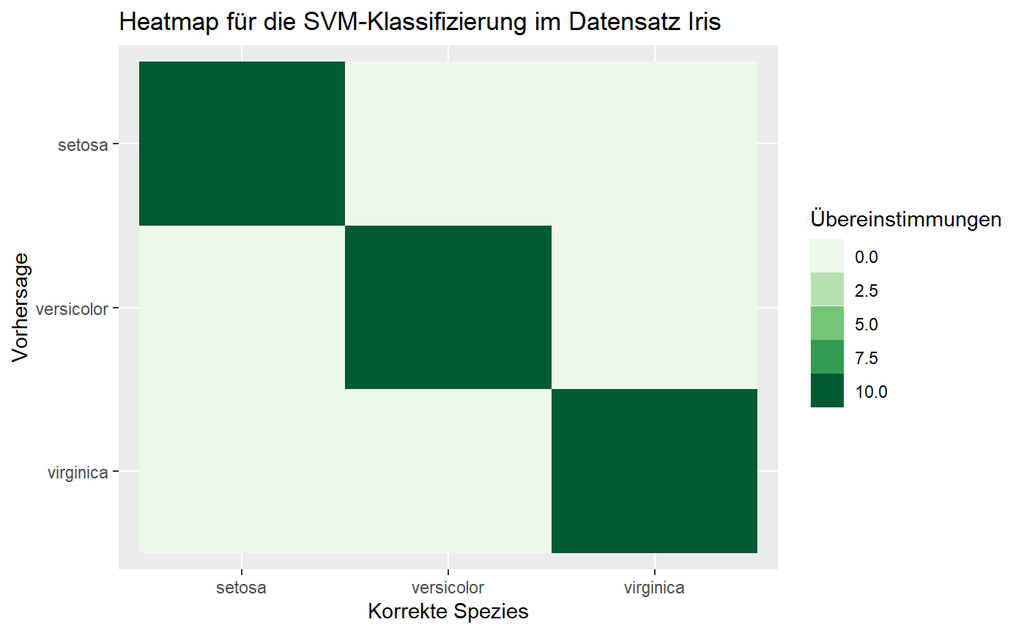

```r
testError <- mean(correct != predictions)

confusion %>%
  as_tibble() %>%
  ggplot() +
  geom_tile(mapping=aes(x=correct,
                        y=factor(predictions, level=level_order),
                        fill=n)) +
  scale_fill_distiller(palette="Greens",
                       guide="legend",
                       limits = c(0, 10),
                       direction=1) +
  guides(fill=guide_legend(title="Übereinstimmungen")) +
  labs(
    title="Heatmap für die SVM-Klassifizierung im Datensatz Iris",
    x="Korrekte Spezies",
    y="Vorhersage"
  )

ggsave(filename="irisSVMHeat.png", plot=last_plot(),
       device="png",
       path="images/",
       width=16, height=9, units="cm")
```

# 6 Clustering

Clustering ist ein Verfahren aus dem unsupervised machine learning. Wir haben keinen y-Wert, den wir vorhersagen können oder eine Information über die Spezies unserer Iris-Pflanzen, sondern wir fragen uns, ob wir auf Grund der vorliegenden Information unsere Daten in cluster einteilen können.

In der Literatur finden wir hier eine Menge von Algorithmen, die *hierarchical clustering* durchführen*. Wir beschränken uns hier auf das* k-means clustering*, um die grundlegende Idee der Cluster-Verfahren kennen zu lernen.

## 6.1 K-means Clustering

Dieser Ansatz für die Bestimmung von Clustern geht davon aus, dass die Benutzer der Funktion eine Information darüber haben, wie viele Cluster es vermutlich gibt. Dies ist das k im Namen des Verfahrens. Im Verfahren werden sogenannte *Zentroide* verwendet. Haben wir eine Menge von Punkten in der Ebene, dann ist das Zentroid einfach der Punkt, den wir erhalten, wenn wir koordinatenweise das arithmetische Mittel bilden.

In der Praxis sollten wir solche Verfahren immer auf standardisierte Daten anwenden. Damit vermeidet man, dass Merkmale mit sehr großen Zahlen vom Algorithmus gegenüber von Merkmalen mit relativ kleinen Werten bevorzugt werden. Wir können bei den Iris-Daten auf diesen Schritt verzichten. Aber in der Praxis hat dieser häufig als *Skalierung* bezeichnete Schritt oft dramatische Auswirkungen auf die Ergebnisse der Cluster-Verfahren.

Der K-Means Algorithmus geht grob skizziert so vor: 1. Wir wählen per Zufall k Punkte als Zentroide aus. 1. Alle restlichen Punkte werden mit Hilfe eines Abstandsbegriffs einem dieser Zentroide zugewiesen. 1. In jeder dieser k Gruppen von Punkten berechnen wir mit Hilfe von Mittelwertbildung ein neues Zentroid. 1. Alle Punkte werden erneut einer der k Gruppen zugewiesen, auf der Basis der neu berechnen Zentroide. 1. Die beiden letzten Schritte werden so lange durchgeführt, bis Abbruchkriterien erreicht werden, zum Beispiel die maximale Anzahl der Wiederholungen.

```r
iris2 <- iris[,-5]
iris.cluster <- kmeans(iris2, 3, nstart=20)

table(iris.cluster$cluster)
```

```
 1  2  3
50 62 38
```

```r
iris.cluster$centers
```

```
  Sepal.Length Sepal.Width Petal.Length Petal.Width
1         5.01        3.43         1.46       0.246
2         5.90        2.75         4.39       1.434
3         6.85        3.07         5.74       2.071
```

```r
table(iris[,5], iris.cluster$cluster)
```

```
              1  2  3
  setosa     50  0  0
  versicolor  0 48  2
  virginica   0 14 36
```

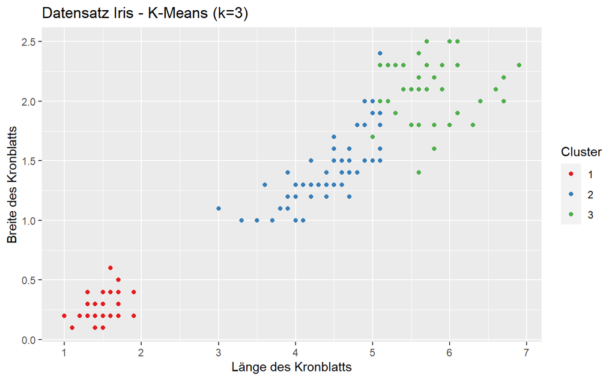

```r
cluster.factor <- factor(iris.cluster$cluster)
ggplot(iris) +
  geom_point(mapping=aes(x = Petal.Length,
                         y = Petal.Width,
                         color = cluster.factor)) +
  scale_x_continuous(breaks = seq(0.0, 8.0)) +
  scale_color_brewer(palette="Set1",
                     guide="legend") +
  guides(color=guide_legend(title="Cluster")) +
  labs(
         title="Datensatz Iris - K-Means (k=3)",
         x = "Länge des Kronblatts",
         y = "Breite des Kronblatts"
  )

ggsave(filename="irisKMScatter.png", plot=last_plot(),
       device="png",
       path="images/",
       width=16, height=9, units="cm")
```

# 7 Literaturverzeichnis

Gareth, Witten, Hastie, and Tibshirani. 2013. *An Introduction to Statistical Learning with Applications in r*. Springer.

Kabacoff, Robert. 2015. *R in Action*. Manning.